# Nitinat escapement 2025 (PRELIM)

South Coast StA

Last update: 2025-11-25

# 1 **Infilling/specialty expansion of specific surveys**

*This section is reserved for deeper dives into specific surveys or days where specialty expansions might be required (e.g., important sections missed, partial surveys around peak of spawn, etc.). This section could be blank in years where no detailed exploration/analysis is needed to determine a survey’s expansion!*

- Oct 8: 3 bears fishing at 2-1, did not swim area to avoid them and missed some fish.
- Oct 16: 5 bears fishing around marker 1 (just u/s; in 2-1), did not swim had to avoid, missed fish.

# 2 **Sockeye**

Snorkel and heli surveys were primarily timed for Chinook and Chum. Sockeye counts are incidental and should be considered low-quality/incomplete.

## 2.1 Area 21-22 raw vs expanded counts

Counts are expanded for both % population surveyed and/or observer efficiency, depending on survey conditions.

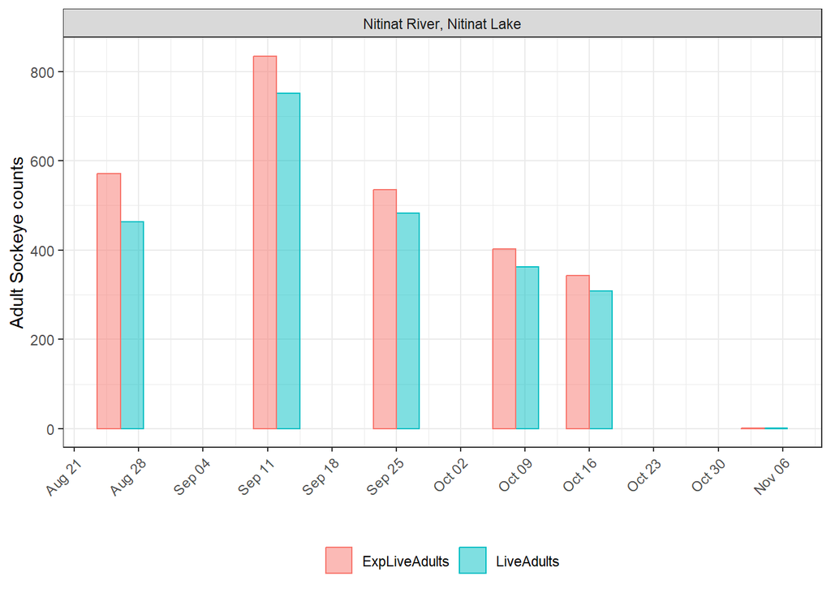

Figure: Observed live Adult sockeye (blue) and the same counts expanded for % population and/or OE (pink).

## 2.2 Counts & environmentals

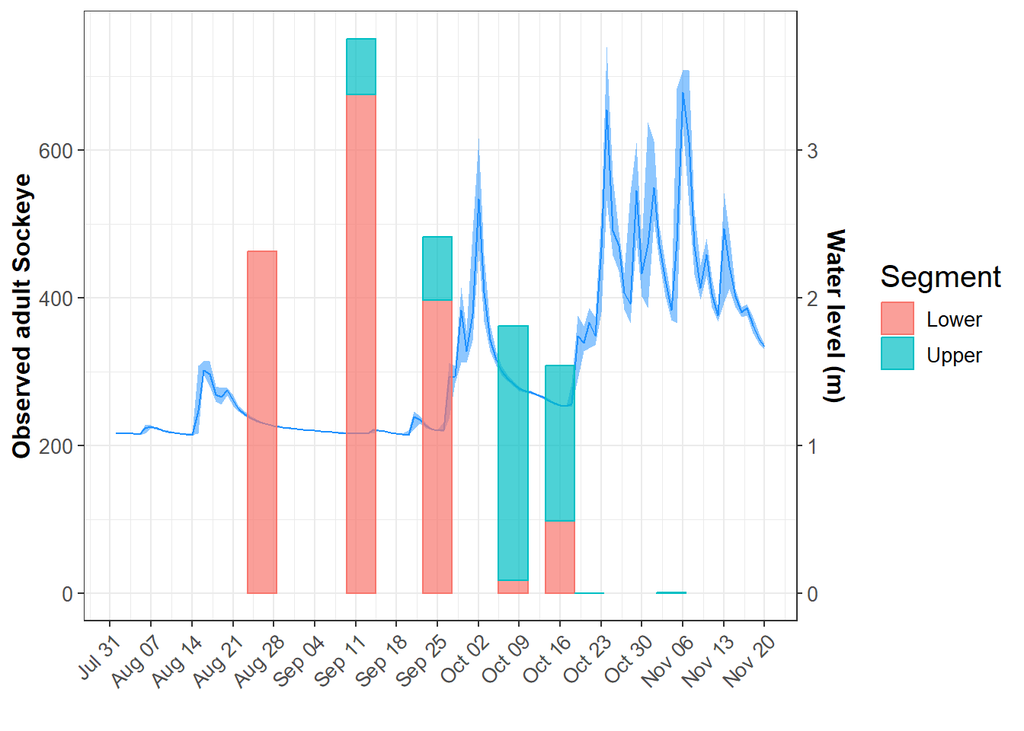

Figure: Sockeye counts (raw live adults), water levels (blue line)

## 2.3 Behaviour & carcasses

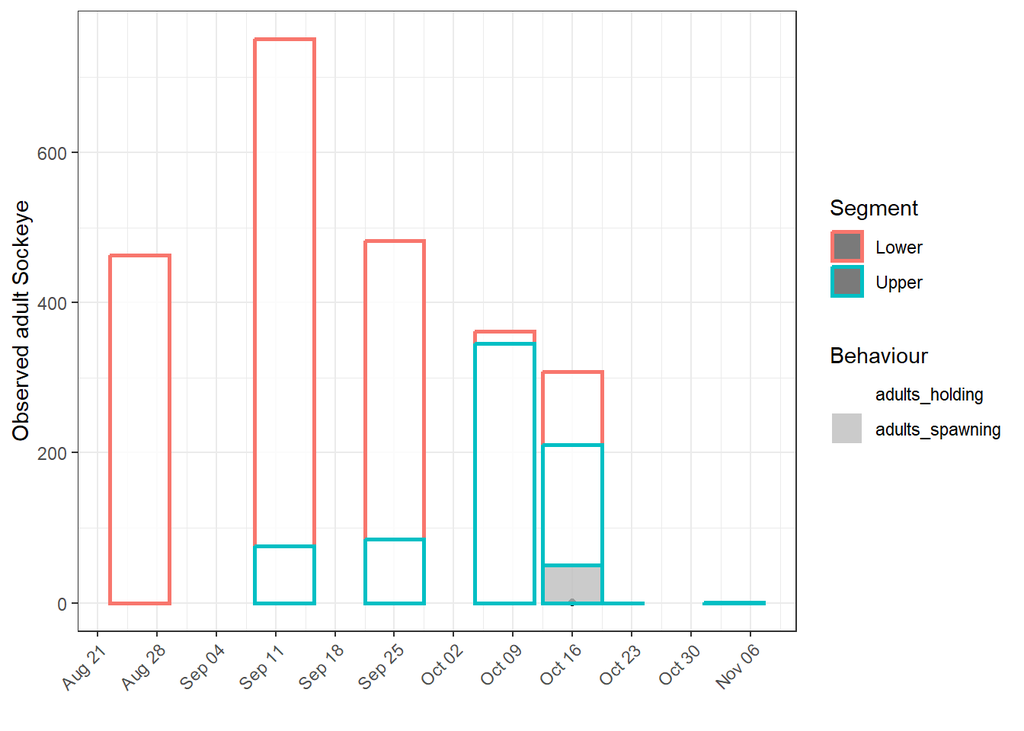

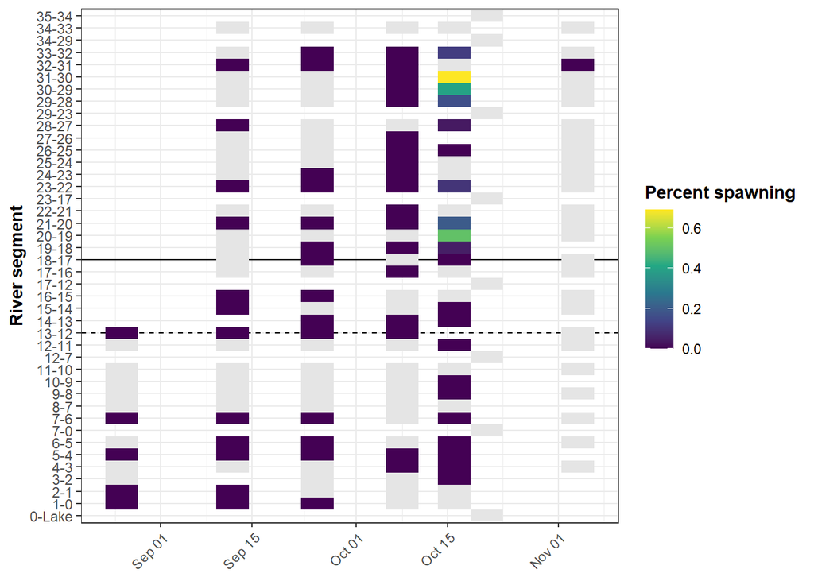

Figure: Sockeye spawning behaviour by reach break over each survey (snorkel and heli, if done). Solid black line denotes the differentiation between upper and lower Nitinat; dashed black line indicates where the hatchery is located along the river. Note heli and snorkel reach breaks are not the same. If any reach break is blank, it implies the surveyors missed the marker, and both reach counts were included in the one before. Counts with no Sockeye and/or no spawning Sockeye are indicated as gray (division by zero).

## 2.4 Snorkel & swim-in counts

There are no swim-ins for Nitinat sockeye as they are not enhanced.

## 2.5 Tributaries (River and Lake)

| date | NAME | ad_live | exp_ad_livve | dead_adults | jk_live | jk_dead |
| --- | --- | --- | --- | --- | --- | --- |
| 2025-04-30 | HOBITON CREEK | 0 | 0 | 0 | 0 | 0 |
| 2025-05-28 | HOBITON CREEK | 0 | 0 | 0 | 0 | 0 |
| 2025-06-17 | HOBITON CREEK | 2500 | 2632 | 0 | 0 | 0 |
| 2025-10-07 | HOBITON CREEK | 0 | 0 | 0 | 0 | 0 |
| 2025-10-21 | LITTLE NITINAT RIVER | 0 | 0 | 0 | 0 | 0 |
| 2025-10-29 | CAMPUS CREEK | 0 | 0 | 0 | 0 | 0 |

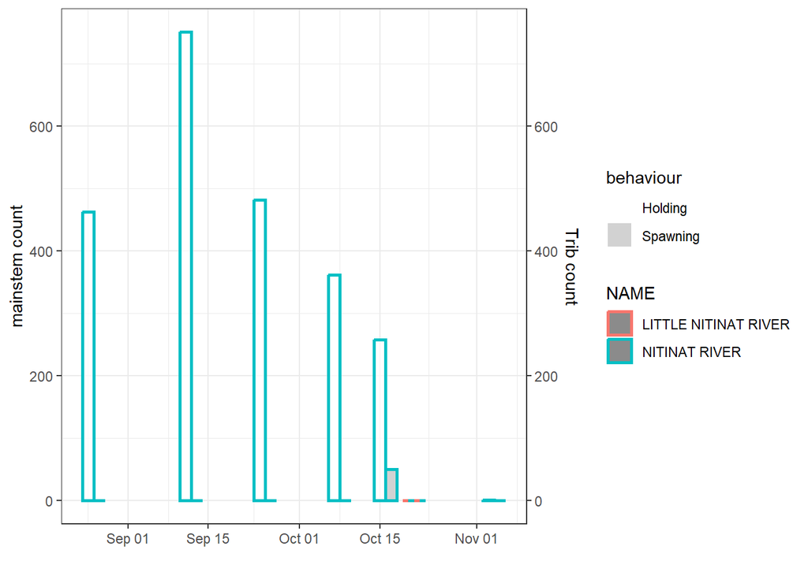

## 2.6 AUC assessments

The information below is meant to assist with determining if AUC is an appropriate method, and whether to include/exclude certain surveys. **Note that removals of surveys that are deemed irrelevant for a species/year has already been in the database prior to exporting the AUCresults file. This script does not really help with that unless you “restore to default” AUC data in the database and do some extra plotting yourself**

Table: AUC math for systems receiving AUC estimate in 2025

```
## # A tibble: 7 × 13
##   WatershedCode            Year ShortSpecies DateRange NoOfDays RawAdultFishDays
##   <chr>                   <dbl> <chr>        <chr>        <dbl>            <dbl>
## 1 930-071700-00000-00000…  2025 SK           2025/07/…       42           9723
## 2 930-071700-00000-00000…  2025 SK           2025/08/…       17          10319
## 3 930-071700-00000-00000…  2025 SK           2025/09/…       13           8014.
## 4 930-071700-00000-00000…  2025 SK           2025/09/…       13           5486
## 5 930-071700-00000-00000…  2025 SK           2025/10/…        8           2680
## 6 930-071700-00000-00000…  2025 SK           2025/10/…       19           2936.
## 7 930-071700-00000-00000…  2025 SK           2025/11/…       11              5.5
## # ℹ 7 more variables: RawJackFishDays <dbl>, ExpAdultFishDays <dbl>,
## #   ExpJackFishDays <dbl>, AREA <chr>, n <int>, SystemName <chr>, method <chr>
```

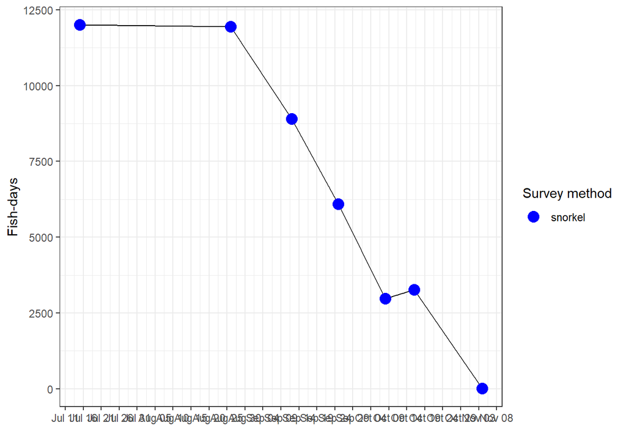

Figure: AUC curve for Nitinat mainstem Sockeye. Note in 2024 this had already excluded the heli survey, but in future would likely also include the flight for reference.

## 2.7 Area 21-22 preliminary escapement estimates

Table: Escapement estimates for each system.

| Year | SystemName | AREA | ShortSpecies | StartingZeroDate | EndingZeroDate | AdultShortResidenceTime | AdultMidResidenceTime_R | AdultLongResidenceTime | JackShortResidenceTime | JackMidResidenceTime_R | JackLongResidenceTime | AUCTotalDays | AdultExpAUCLowValue | AdultExpAUCMidValue_R | AdultExpAUCHighValue | JackExpAUCLowValue | JackExpAUCMidValue_R | JackExpAUCHighValue | AdultExpPLD | JackExpPLD | FinalAdultEstimate | AdultRemovalsReco | FinalJackEstimate | JackRemovalsReco | AdultRemovalsIncluded | JackRemovalsIncluded | EnumerationClass | IsFinal |
| --- | --- | --- | --- | --- | --- | --- | --- | --- | --- | --- | --- | --- | --- | --- | --- | --- | --- | --- | --- | --- | --- | --- | --- | --- | --- | --- | --- | --- |
| 2025 | Nitinat River, Nitinat Lake | 22 | SK | 2025-07-15 | 2025-11-15 | 30 | 35 | 40 | 30 | 35 | 40 | 123 | 1130 | 1292 | 1507 | 28 | 32 | 37 | 834 | 60 | 0 | 0 | 0 | 0 | FALSE | FALSE | 4 | FALSE |

### 2.7.1 Estimate decision:

## 2.8 2025 compared to historical run timing and abundance

Run timing information is not available for Nitinat Sockeye.

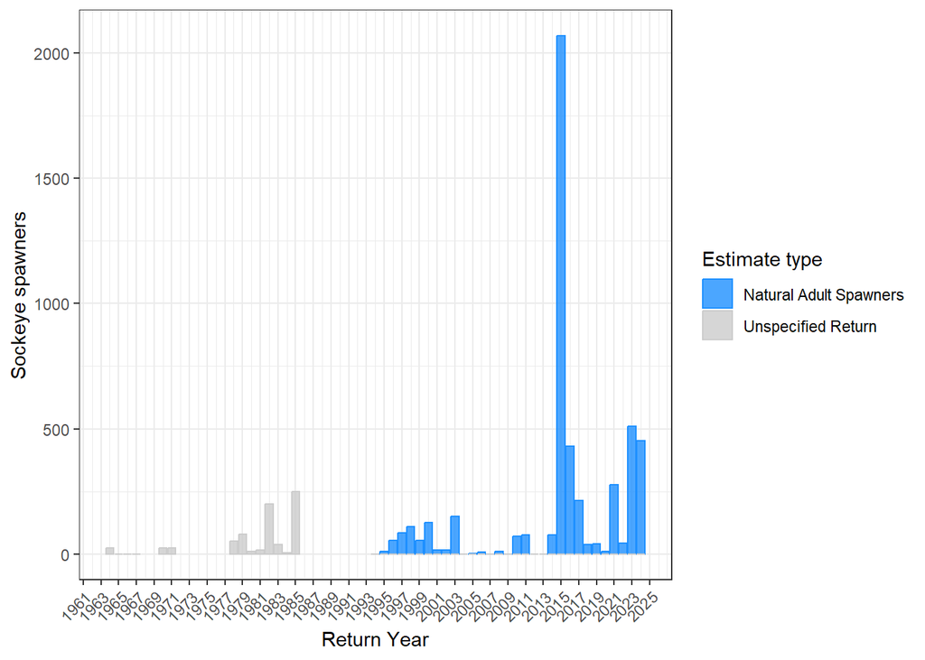

# 3 **Coho**

## 3.1 Area 21-22 raw vs expanded counts

Counts are expanded for both % population surveyed and/or observer efficiency, depending on survey conditions.

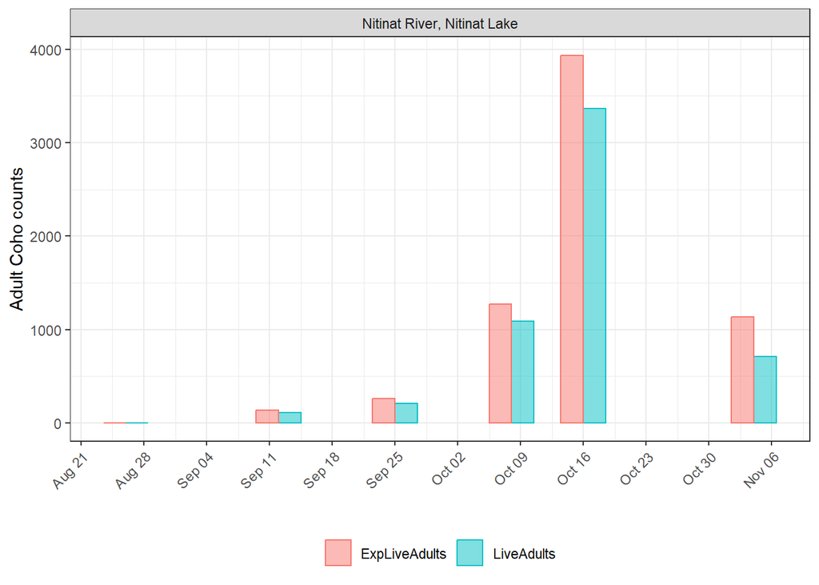

s Figure: Observed Adult Coho (blue) and the same counts expanded for % population and/or OE (pink).

## 3.3 Behaviour & carcasses

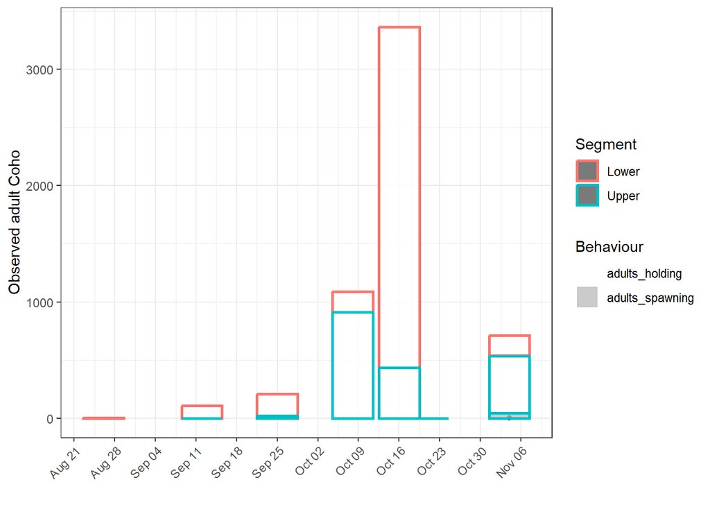

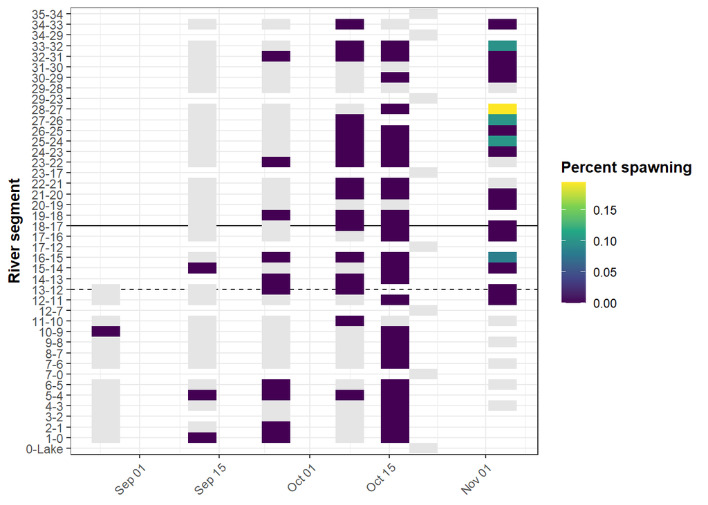

Figure: Coho spawning behaviour by reach break over each survey (snorkel and heli, if done). Solid black line denotes the differentiation between upper and lower Nitinat; dashed black line indicates where the hatchery is located along the river. Note heli and snorkel reach breaks are not the same. If any reach break is blank, it implies the surveyors missed the marker, and both reach counts were included in the one before. Counts with no Coho and/or no spawning Coho are indicated as gray (division by zero).

## 3.4 Snorkel, angling & swim-in counts

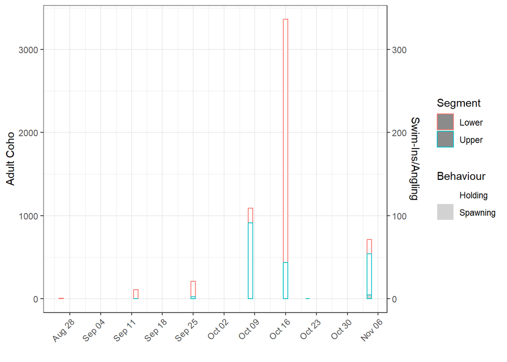

## 3.5 Mark rate in lake

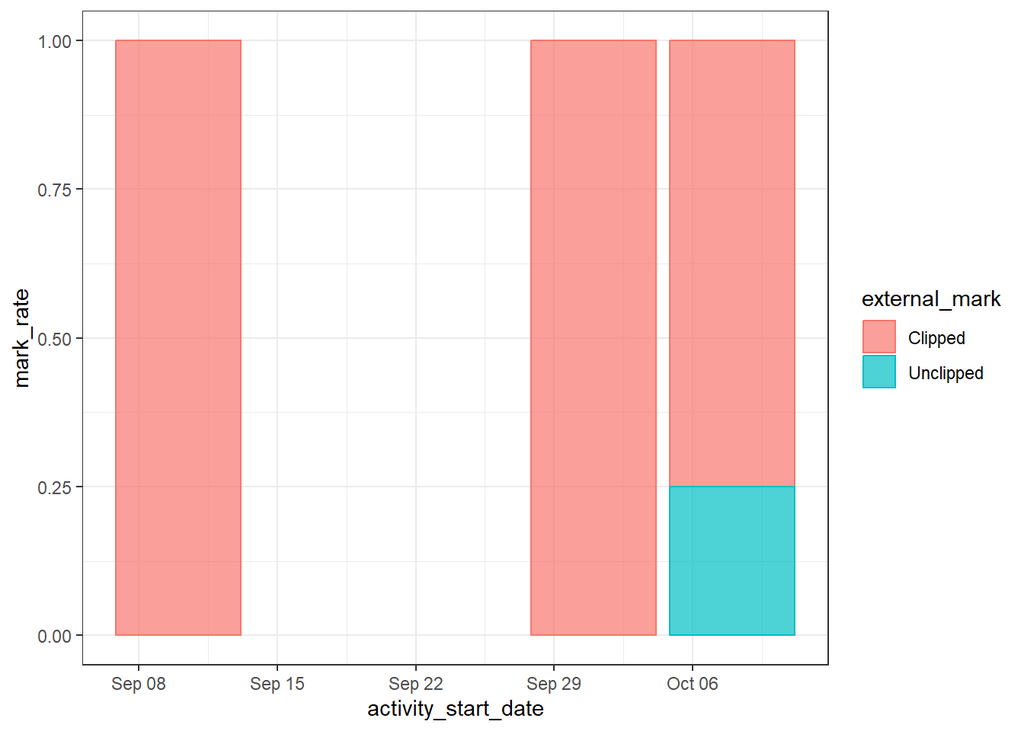

Figure: Mark rate of all coho caught in purse seine catches in Nitinat Lake. Excluded gillnet catch as mark rate is typically not examined.

The overall mark rate of **ALL coho** caught in Nitinat Lake purse seine this year was **79.8%**.

The overall mark rate of **ADULT coho** caught in Nitinat Lake purse seine this year was **75.7%**.

## 3.6 Tributaries (River and Lake)

| date | NAME | ad_live | exp_ad_livve | dead_adults | jk_live | jk_dead |
| --- | --- | --- | --- | --- | --- | --- |
| 2025-04-30 | HOBITON CREEK | 0 | 0 | 0 | 0 | 0 |
| 2025-05-28 | HOBITON CREEK | 0 | 0 | 0 | 0 | 0 |
| 2025-06-17 | HOBITON CREEK | 0 | 0 | 0 | 0 | 0 |
| 2025-10-07 | HOBITON CREEK | 0 | 0 | 0 | 0 | 0 |
| 2025-10-21 | LITTLE NITINAT RIVER | 0 | 0 | 0 | 0 | 0 |
| 2025-10-29 | CAMPUS CREEK | 3 | 4 | 0 | 0 | 0 |

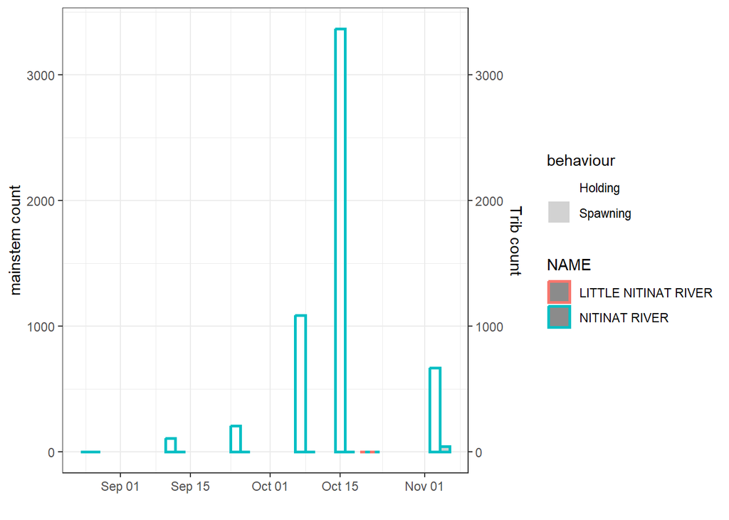

## 3.7 AUC assessments

The information below is meant to assist with determining if AUC is an appropriate method, and whether to include/exclude certain surveys.

Table: AUC math for systems receiving AUC estimate in 2025

```
## # A tibble: 7 × 13
##   WatershedCode            Year ShortSpecies DateRange NoOfDays RawAdultFishDays
##   <chr>                   <dbl> <chr>        <chr>        <dbl>            <dbl>
## 1 930-071700-00000-00000…  2025 CO           2025/08/…       11              5.5
## 2 930-071700-00000-00000…  2025 CO           2025/08/…       17            935
## 3 930-071700-00000-00000…  2025 CO           2025/09/…       13           2067
## 4 930-071700-00000-00000…  2025 CO           2025/09/…       13           8437
## 5 930-071700-00000-00000…  2025 CO           2025/10/…        8          17816
## 6 930-071700-00000-00000…  2025 CO           2025/10/…       19          38741
## 7 930-071700-00000-00000…  2025 CO           2025/11/…       57          20320.
## # ℹ 7 more variables: RawJackFishDays <dbl>, ExpAdultFishDays <dbl>,
## #   ExpJackFishDays <dbl>, AREA <chr>, n <int>, SystemName <chr>, method <chr>
```

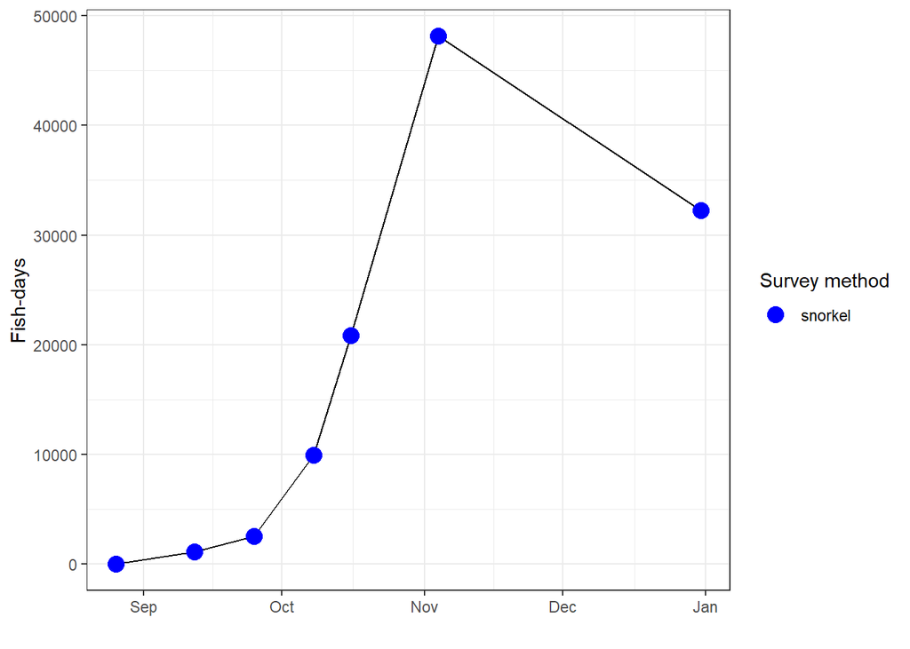

Figure: AUC curve for Nitinat mainstem Coho. Note in 2023 this had already excluded the heli survey, but in future would likely also include the flight for reference.

## 3.8 Area 21-22 preliminary escapement estimates (AUC/PL+D)

| Year | SystemName | AREA | ShortSpecies | StartingZeroDate | EndingZeroDate | AdultShortResidenceTime | AdultMidResidenceTime_R | AdultLongResidenceTime | JackShortResidenceTime | JackMidResidenceTime_R | JackLongResidenceTime | AUCTotalDays | AdultExpAUCLowValue | AdultExpAUCMidValue_R | AdultExpAUCHighValue | JackExpAUCLowValue | JackExpAUCMidValue_R | JackExpAUCHighValue | AdultExpPLD | JackExpPLD | FinalAdultEstimate | AdultRemovalsReco | FinalJackEstimate | JackRemovalsReco | AdultRemovalsIncluded | JackRemovalsIncluded | EnumerationClass | IsFinal |
| --- | --- | --- | --- | --- | --- | --- | --- | --- | --- | --- | --- | --- | --- | --- | --- | --- | --- | --- | --- | --- | --- | --- | --- | --- | --- | --- | --- | --- |
| 2025 | Nitinat River, Nitinat Lake | 22 | CO | 2025-08-15 | 2025-12-31 | 25 | 30 | 35 | 25 | 30 | 35 | 138 | 3284 | 3831 | 4597 | 453 | 528 | 634 | 0 | 0 | 0 | 0 | 0 | 0 | FALSE | FALSE | 0 | FALSE |

### 3.8.1 Estimate decision:

## 3.9 2025 compared to historical run timing and abundance

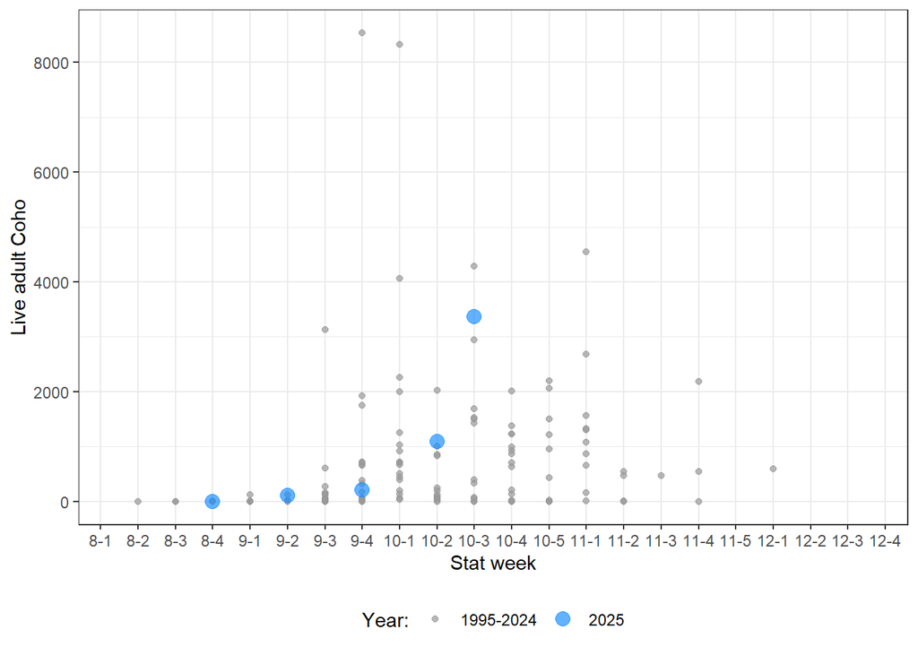

Figure: Raw swim counts (blue) from this year compared to historical raw swim counts. Stat weeks indicate the month (8=August, 12=December) and week of momth (1=first week, 2=2nd week, etc.), e.g., 81=First week of August, 91=First week of September, etc.

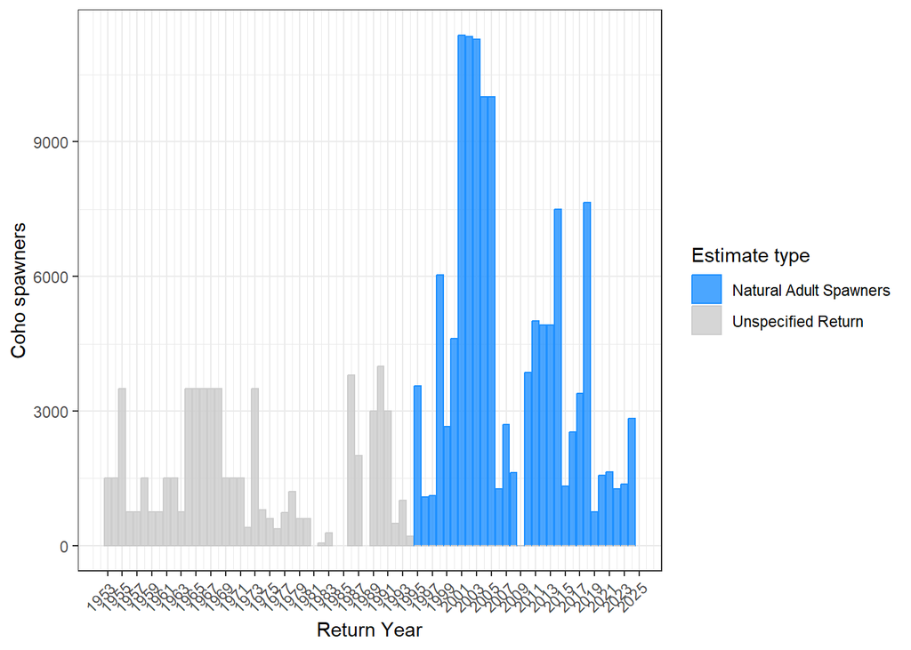

# 4 **Chum**

## 4.1 Area 21-22 raw vs expanded counts

Counts are expanded for both % population surveyed and/or observer efficiency, depending on survey conditions.

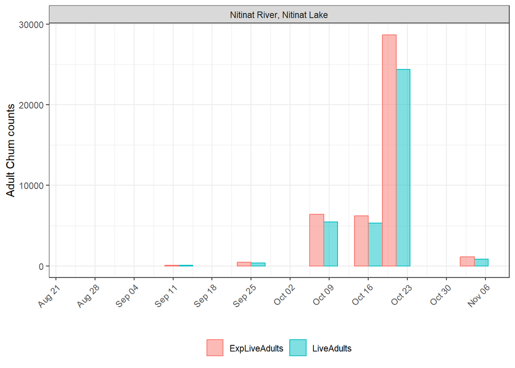

Figure: Observed Adult Chum (blue) and the same counts expanded for % population and/or OE (pink).

## 4.2 Counts & environmentals

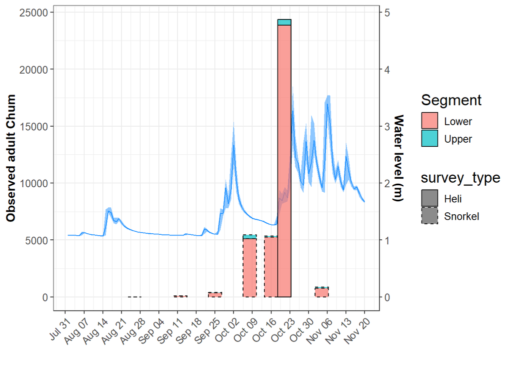

Figure: Chum counts (raw live adults), water levels (blue line)

## 4.3 Behaviour & carcasses

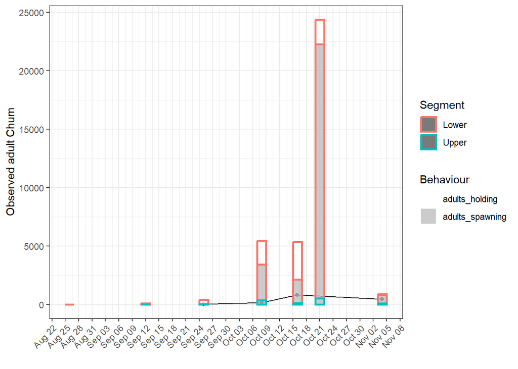

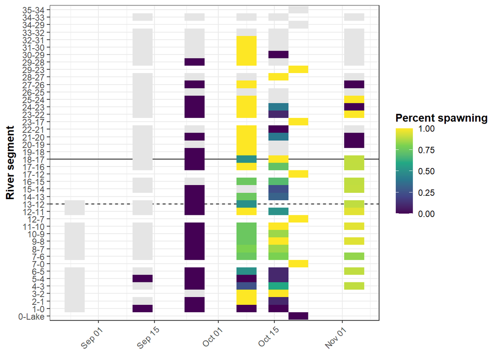

Figure: Chum spawning behaviour by reach break over each survey (snorkel and heli, if done). Solid black line denotes the differentiation between upper and lower Nitinat; dashed black line indicates where the hatchery is located along the river. Note heli and snorkel reach breaks are not the same. If any reach break is blank, it implies the surveyors missed the marker, and both reach counts were included in the one before. Counts with no Chum and/or no spawning Chum are indicated as gray (division by zero).

## 4.4 Snorkel & swim-in counts

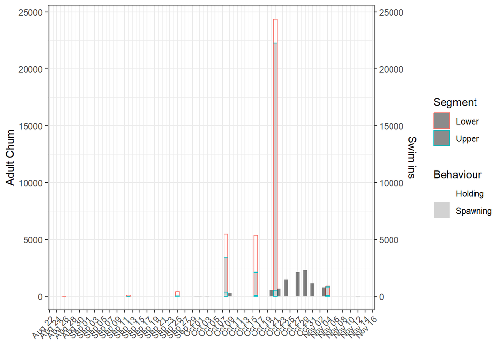

Figure: Expanded Chum counts (large bars) and swim-ins (narrow black bars). Adult bar fill colours indicate behaviour (spawning=gray, holding=white), bar line colour indicates river segment (lower=pink, upper=blue).

## 4.5 Tributaries (River and Lake)

| date | NAME | ad_live | exp_ad_livve | dead_adults | jk_live | jk_dead |
| --- | --- | --- | --- | --- | --- | --- |
| 2025-04-30 | HOBITON CREEK | 0 | 0 | 0 | 0 | 0 |
| 2025-05-28 | HOBITON CREEK | 0 | 0 | 0 | 0 | 0 |
| 2025-06-17 | HOBITON CREEK | 0 | 0 | 0 | 0 | 0 |
| 2025-10-07 | HOBITON CREEK | 535 | 606 | 0 | 0 | 0 |
| 2025-10-21 | LITTLE NITINAT RIVER | 22 | 22 | 0 | 0 | 0 |
| 2025-10-29 | CAMPUS CREEK | 103 | 129 | 19 | 0 | 0 |

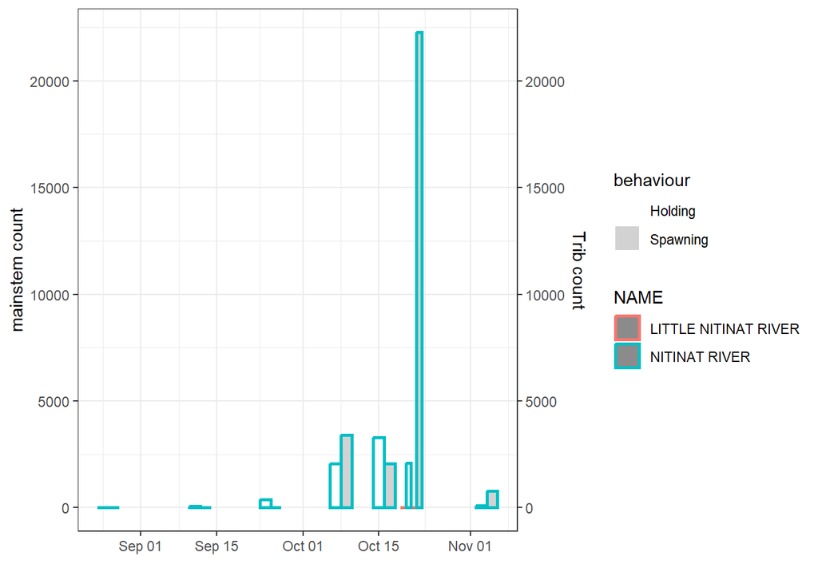

## 4.6 AUC assessments

The information below is meant to assist with determining if AUC is an appropriate method, and whether to include/exclude certain surveys.

Table: AUC math for systems receiving AUC estimate in 2025

```
## # A tibble: 8 × 13
##   WatershedCode            Year ShortSpecies DateRange NoOfDays RawAdultFishDays
##   <chr>                   <dbl> <chr>        <chr>        <dbl>            <dbl>
## 1 930-071700-00000-00000…  2025 CM           2025/08/…        1               0
## 2 930-071700-00000-00000…  2025 CM           2025/08/…       17             672.
## 3 930-071700-00000-00000…  2025 CM           2025/09/…       13            3055
## 4 930-071700-00000-00000…  2025 CM           2025/09/…       13           38044.
## 5 930-071700-00000-00000…  2025 CM           2025/10/…        8           43184
## 6 930-071700-00000-00000…  2025 CM           2025/10/…        5           74260
## 7 930-071700-00000-00000…  2025 CM           2025/10/…       14          176624
## 8 930-071700-00000-00000…  2025 CM           2025/11/…       26           11206
## # ℹ 7 more variables: RawJackFishDays <dbl>, ExpAdultFishDays <dbl>,
## #   ExpJackFishDays <dbl>, AREA <chr>, n <int>, SystemName <chr>, method <chr>
```

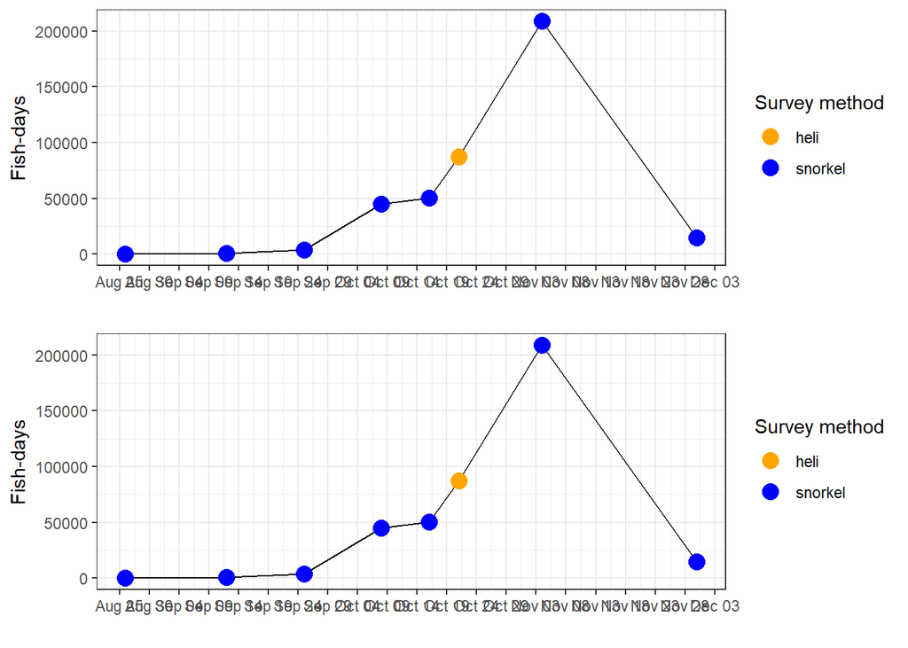

Figure: AUC curve for Nitinat mainstem Chum.

## 4.7 Area 21-22 preliminary escapement estimates (AUC)

Table: Escapement estimates for each system.

| Year | SystemName | AREA | ShortSpecies | StartingZeroDate | EndingZeroDate | AdultShortResidenceTime | AdultMidResidenceTime_R | AdultLongResidenceTime | JackShortResidenceTime | JackMidResidenceTime_R | JackLongResidenceTime | AUCTotalDays | AdultExpAUCLowValue | AdultExpAUCMidValue_R | AdultExpAUCHighValue | JackExpAUCLowValue | JackExpAUCMidValue_R | JackExpAUCHighValue | AdultExpPLD | JackExpPLD | FinalAdultEstimate | AdultRemovalsReco | FinalJackEstimate | JackRemovalsReco | AdultRemovalsIncluded | JackRemovalsIncluded | EnumerationClass | IsFinal |
| --- | --- | --- | --- | --- | --- | --- | --- | --- | --- | --- | --- | --- | --- | --- | --- | --- | --- | --- | --- | --- | --- | --- | --- | --- | --- | --- | --- | --- |
| 2025 | Nitinat River, Nitinat Lake | 22 | CM | 2025-09-01 | 2025-11-30 | 8 | 9 | 10 | 8 | 9 | 10 | 97 | 41052 | 45613 | 51315 | 0 | 0 | 0 | 28671 | 0 | 0 | 0 | 0 | 0 | FALSE | FALSE | 3 | FALSE |

## 4.8 2025 compared to historical run timing

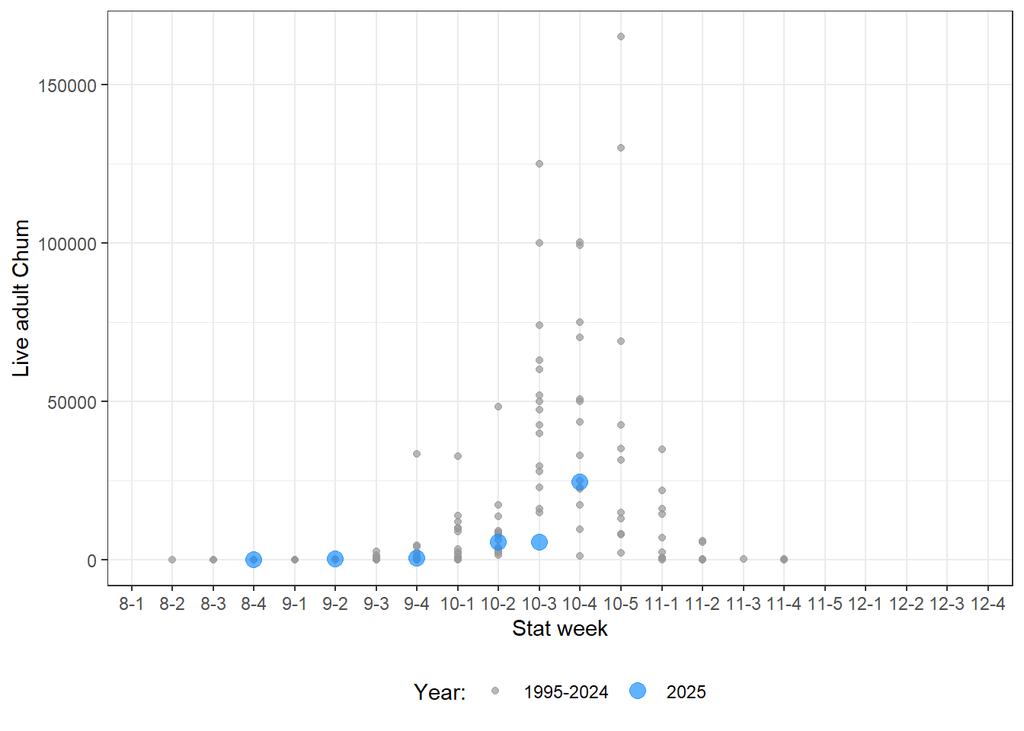

Figure: Raw swim counts (blue) from this year compared to historical raw swim counts. Stat weeks indicate the month (8=August, 12=December) and week of momth (1=first week, 2=2nd week, etc.), e.g., 81=First week of August, 91=First week of September, etc.

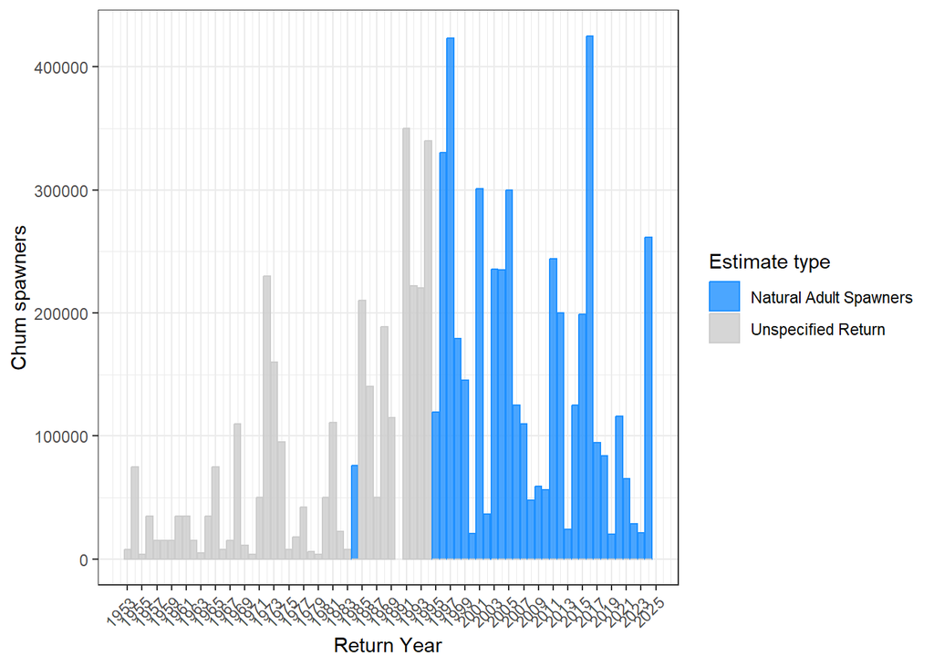

# 5 **Chinook**

## 5.1 Area 21-22 raw vs expanded counts

Counts are expanded for both % population surveyed and/or observer efficiency, depending on survey conditions.

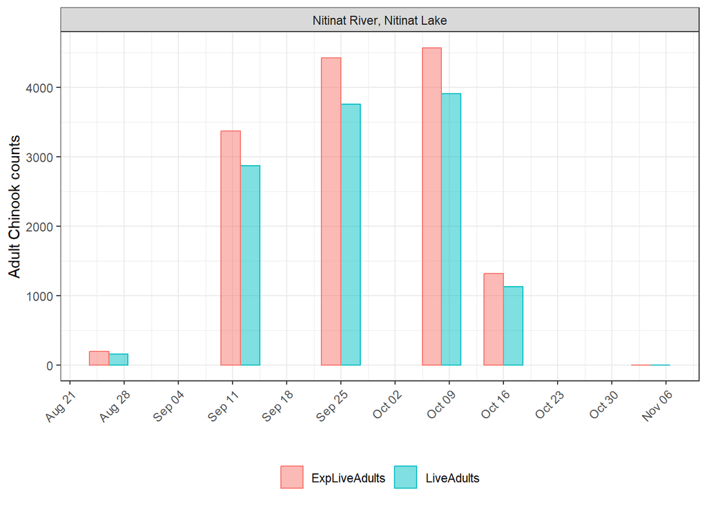

Figure: Observed Adult Chinook (blue) and the same counts expanded for % population and/or OE (pink).

## 5.2 Counts & environmentals

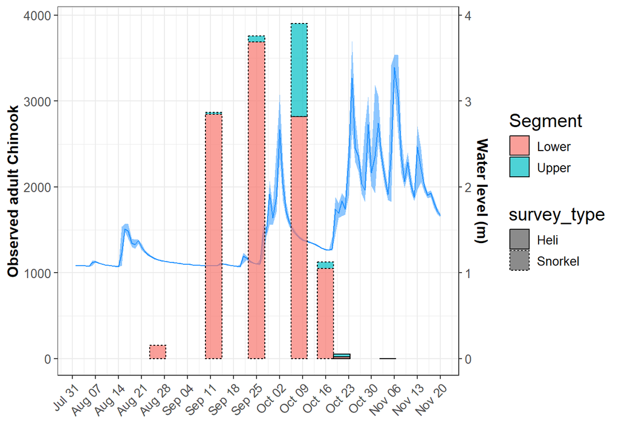

Figure: Chinook counts (raw live adults), water levels (blue line)

## 5.3 Behaviour & carcasses

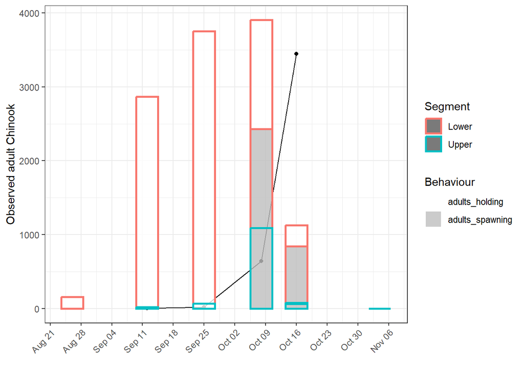

Figure: Expanded live adult Chinook (bars) and carcasses (black line). Bar fill indicates behaviour (spawning=gray, holding=white), bar outline indicates river segment (upper=blue, lower=pink).

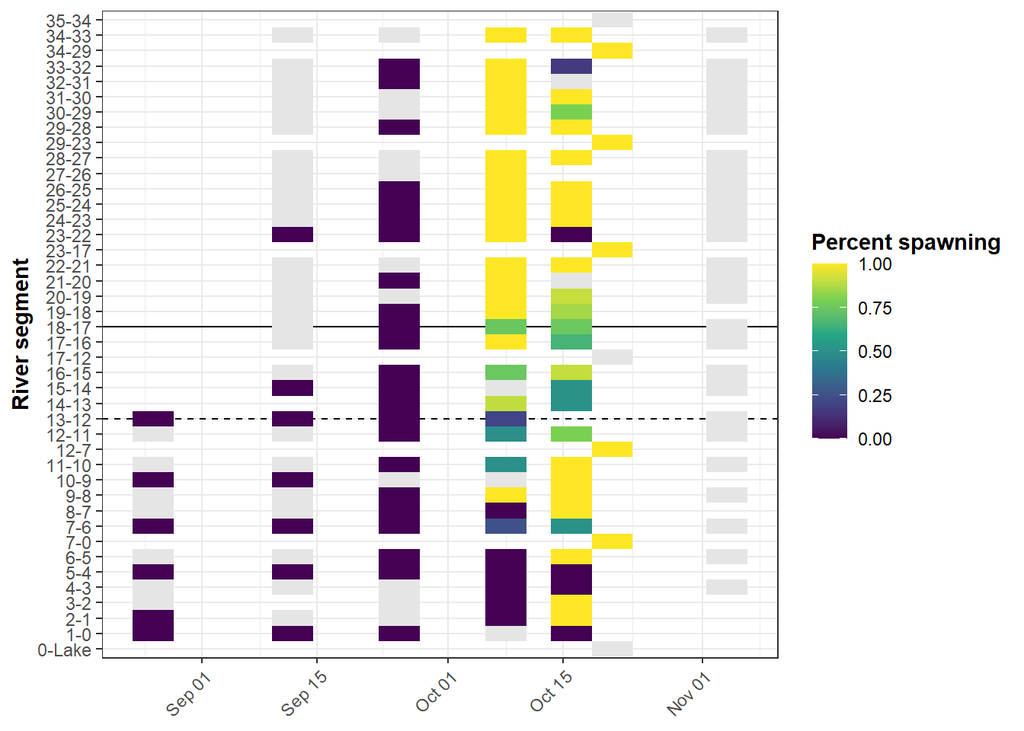

Figure: Chinook spawning behaviour by reach break over each survey (snorkel and heli, if done). Solid black line denotes the differentiation between upper and lower Nitinat; dashed black line indicates where the hatchery is located along the river. Note heli and snorkel reach breaks are not the same. If any reach break is blank, it implies the surveyors missed the marker, and both reach counts were included in the one before. Counts with no Chinook and/or no spawning Chinook are indicated as gray (division by zero).

## 5.4 Snorkel, river seine & swim-in counts

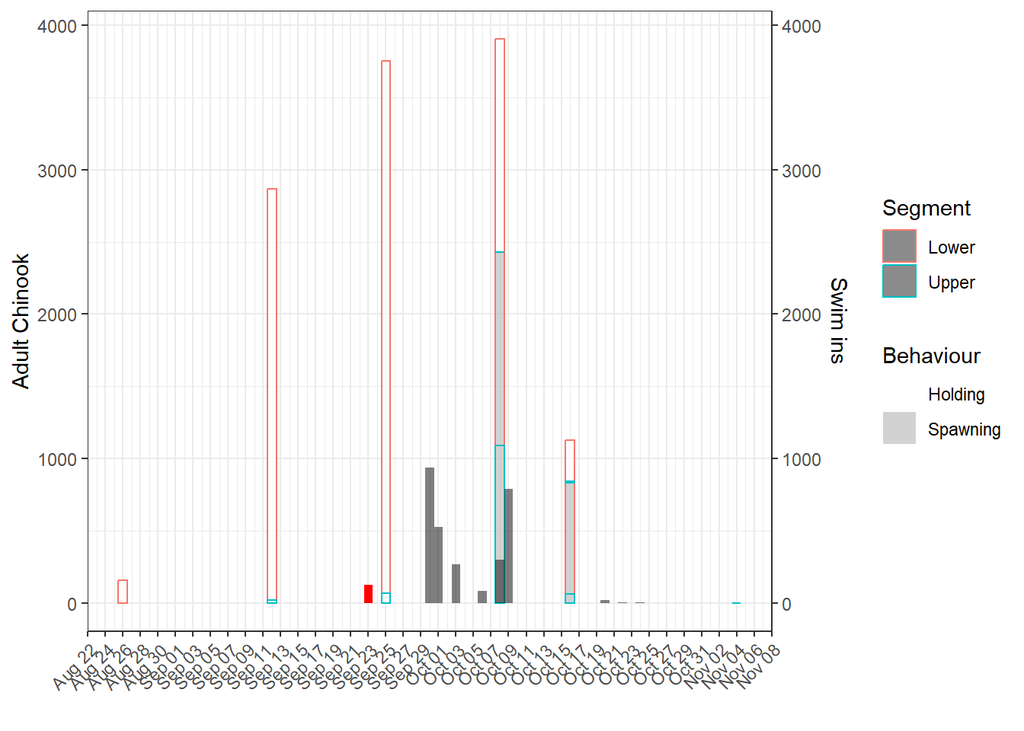

Figure: Expanded adult Chinook counts (large bars) and swim-ins (narrow black bars). Adult bar fill colours indicate behaviour (spawning=gray, holding=white), bar line colour indicates river segment (lower=pink, upper=blue). If a solid red bar is present, this indicates a river beach seine event for broodstock collection.

Total number of swim-ins this year is: 2920, of which 2695 were adults.

The total number collected from river beach seining is: 124, of which 118 were adults.

## 5.5 Tributaries (River and Lake)

The following section is largely to help with determining whether Nitinat River trib counts (Parker, Worthless, Jasper, NoName, Little Nitinat) need to be in addition to the mainstem count, or if we think the fish that ended up in the tribs were captured in the mainstem swims (so don’t need to be in addition to, and should be subtracted from the mainstem count).

In some years there aren’t tributary surveys, so this may not apply.

| date | NAME | ad_live | exp_ad_livve | dead_adults | jk_live | jk_dead |
| --- | --- | --- | --- | --- | --- | --- |
| 2025-04-30 | HOBITON CREEK | 0 | 0 | 0 | 0 | 0 |
| 2025-05-28 | HOBITON CREEK | 0 | 0 | 0 | 0 | 0 |
| 2025-06-17 | HOBITON CREEK | 0 | 0 | 0 | 0 | 0 |
| 2025-10-07 | HOBITON CREEK | 6 | 7 | 0 | 0 | 0 |
| 2025-10-21 | LITTLE NITINAT RIVER | 0 | 0 | 0 | 0 | 0 |
| 2025-10-29 | CAMPUS CREEK | 0 | 0 | 0 | 0 | 0 |

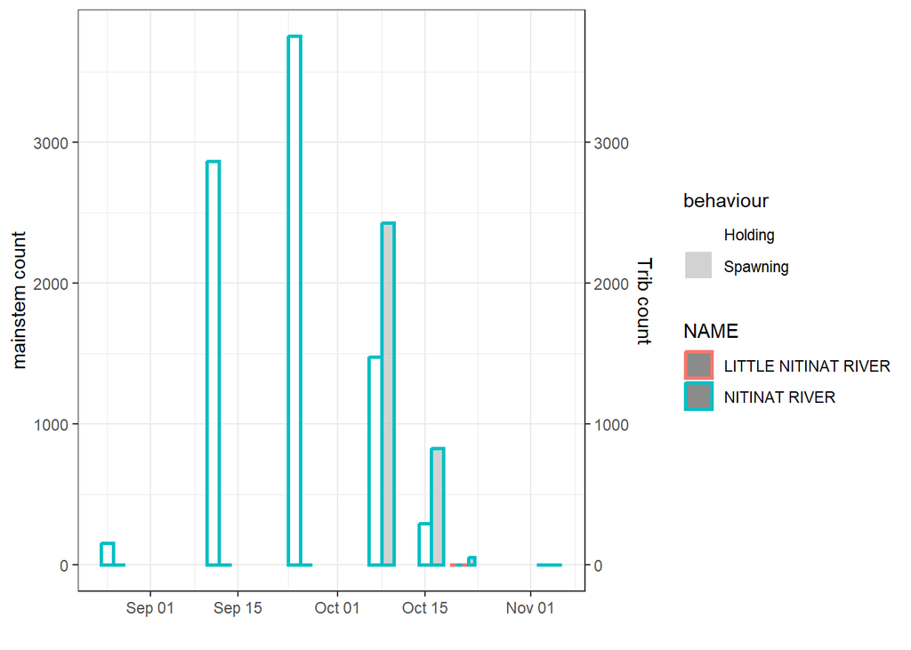

## 5.6 AUC assessments

The information below is meant to assist with determining if AUC is an appropriate method, and whether to include/exclude certain surveys.

Table: AUC math for systems receiving AUC estimate in 2025

```
## # A tibble: 7 × 13
##   WatershedCode            Year ShortSpecies DateRange NoOfDays RawAdultFishDays
##   <chr>                   <dbl> <chr>        <chr>        <dbl>            <dbl>
## 1 930-071700-00000-00000…  2025 CN           2025/08/…       25            1950
## 2 930-071700-00000-00000…  2025 CN           2025/08/…       17           25696.
## 3 930-071700-00000-00000…  2025 CN           2025/09/…       13           43050.
## 4 930-071700-00000-00000…  2025 CN           2025/09/…       13           49803
## 5 930-071700-00000-00000…  2025 CN           2025/10/…        8           20128
## 6 930-071700-00000-00000…  2025 CN           2025/10/…       19               0
## 7 930-071700-00000-00000…  2025 CN           2025/11/…        1               0
## # ℹ 7 more variables: RawJackFishDays <dbl>, ExpAdultFishDays <dbl>,
## #   ExpJackFishDays <dbl>, AREA <chr>, n <int>, SystemName <chr>, method <chr>
```

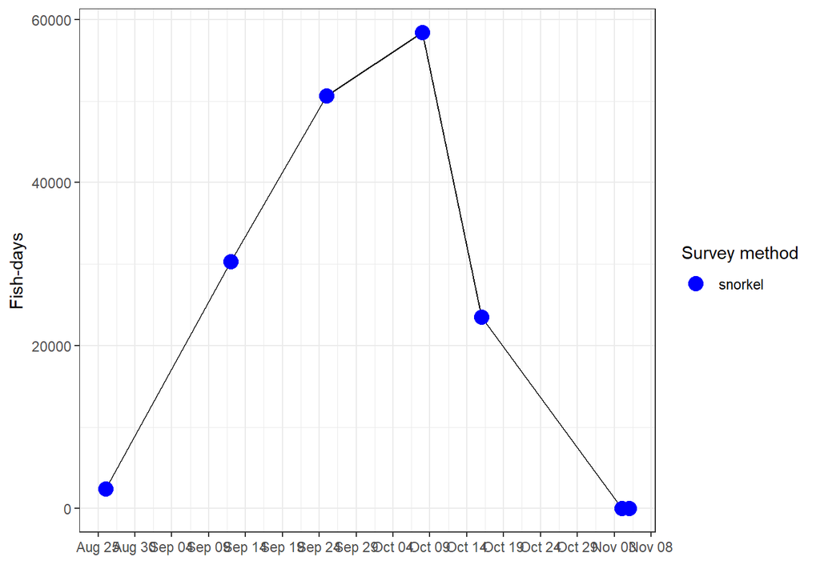

Figure: AUC curve for Nitinat mainstem Chinook.

## 5.7 Area 21-22 preliminary escapement estimates (AUC/PL+D)

Table: Escapement estimate options (AUC/PL+D) for each system.

| Year | SystemName | AREA | ShortSpecies | StartingZeroDate | EndingZeroDate | AdultShortResidenceTime | AdultMidResidenceTime_R | AdultLongResidenceTime | JackShortResidenceTime | JackMidResidenceTime_R | JackLongResidenceTime | AUCTotalDays | AdultExpAUCLowValue | AdultExpAUCMidValue_R | AdultExpAUCHighValue | JackExpAUCLowValue | JackExpAUCMidValue_R | JackExpAUCHighValue | AdultExpPLD | JackExpPLD | FinalAdultEstimate | AdultRemovalsReco | FinalJackEstimate | JackRemovalsReco | AdultRemovalsIncluded | JackRemovalsIncluded | EnumerationClass | IsFinal |
| --- | --- | --- | --- | --- | --- | --- | --- | --- | --- | --- | --- | --- | --- | --- | --- | --- | --- | --- | --- | --- | --- | --- | --- | --- | --- | --- | --- | --- |
| 2025 | Nitinat River, Nitinat Lake | 22 | CN | 2025-08-01 | 2025-11-04 | 12 | 17 | 22 | 12 | 17 | 22 | 96 | 7515 | 9725 | 13778 | 407 | 527 | 746 | 5245 | 372 | 0 | 0 | 0 | 0 | FALSE | FALSE | 3 | FALSE |

### 5.7.1 Estimate decision:

Prior to this RMarkdown script I had already decided to omit the heli survey this year as it was not timed well for Chinook, and the counting was difficult in cases where Chinook might be post-spawn (pools, edges). This is reflected in most, if not all of the graphs with the survey omitted.

Opted for the middle-range SL for AUC for the preliminary estimate as the run timing was normal, despite the lake turnover events, low early water, and overall odd year for Chum arrival (late). Chinook entered the system early Sept which may have been a bit late, but was not linked to much of a rain event. Chinook already peaked in the system by the major rains, and spawn/die-off timing was relatively normal and predictable. No tributaries to account for this year.

## 5.8 2025 compared to historical run timing and abundances

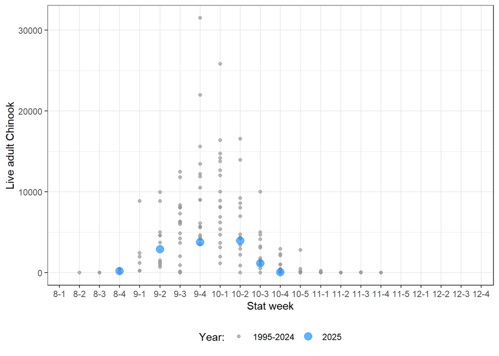

Figure: Raw swim counts (blue) from this year compared to historical raw swim counts. Stat weeks indicate the month (8=August, 12=December) and week of momth (1=first week, 2=2nd week, etc.), e.g., 81=First week of August, 91=First week of September, etc.

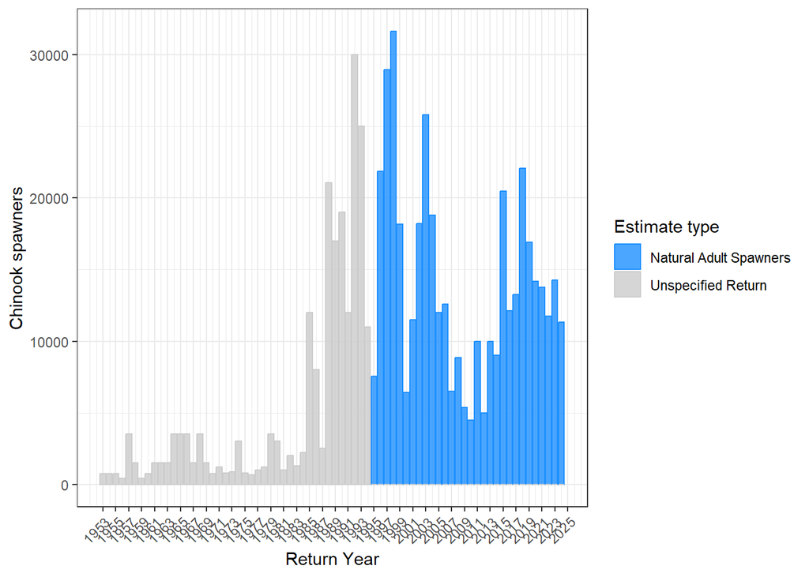

# 6 **Pink**

No consistent WCVI pink runs.

## 6.1 Area 21-22 raw vs expanded counts

Counts are expanded for both % population surveyed and/or observer efficiency, depending on survey conditions.

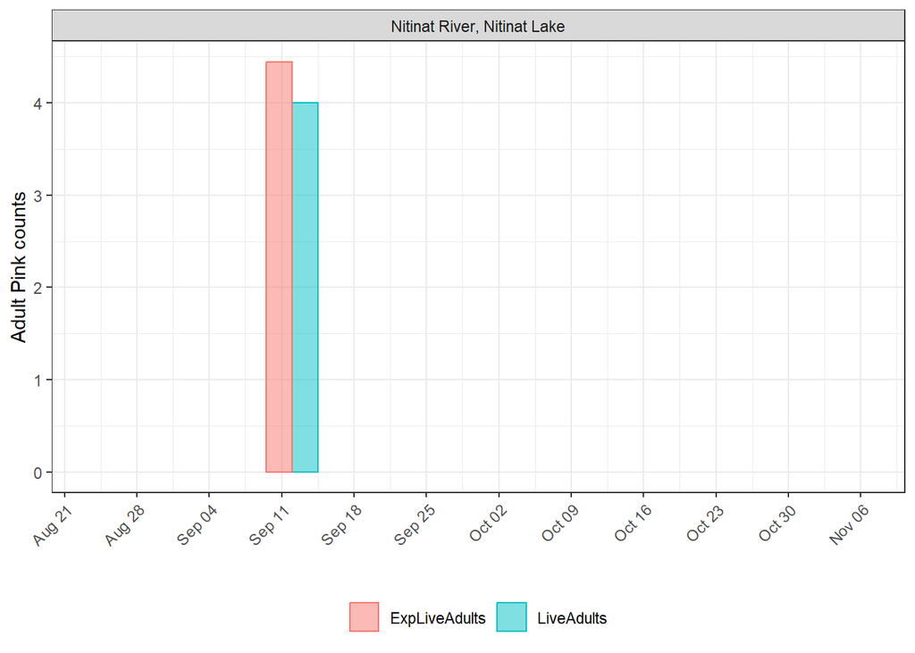

## 6.2 Area 21-22 preliminary escapement estimates

Table: Escapement estimates for each system.

| Year | SystemName | AREA | ShortSpecies | StartingZeroDate | EndingZeroDate | AdultShortResidenceTime | AdultMidResidenceTime_R | AdultLongResidenceTime | JackShortResidenceTime | JackMidResidenceTime_R | JackLongResidenceTime | AUCTotalDays | AdultExpAUCLowValue | AdultExpAUCMidValue_R | AdultExpAUCHighValue | JackExpAUCLowValue | JackExpAUCMidValue_R | JackExpAUCHighValue | AdultExpPLD | JackExpPLD | FinalAdultEstimate | AdultRemovalsReco | FinalJackEstimate | JackRemovalsReco | AdultRemovalsIncluded | JackRemovalsIncluded | EnumerationClass | IsFinal |
| --- | --- | --- | --- | --- | --- | --- | --- | --- | --- | --- | --- | --- | --- | --- | --- | --- | --- | --- | --- | --- | --- | --- | --- | --- | --- | --- | --- | --- |
| 2025 | Nitinat River, Nitinat Lake | 22 | PK | 2025-09-01 | 2025-11-15 | 15 | 20 | 25 | 15 | 20 | 25 | 82 | 2 | 2 | 3 | 0 | 0 | 0 | 4 | 0 | 4 | 0 | 0 | 0 | FALSE | FALSE | 4 | TRUE |

### 6.2.1 Estimate decision:

PL+D wherever seen.

## 6.3 2025 compared to historical escapement

[figure not shown]